# The What, Why, and How of Uncertainty Visualisation

# Part 3: How to (safely) make uncertainty visualisations in `ggdibbler`

## Whoopsie

Breaking the data-visual connection is shockingly easy

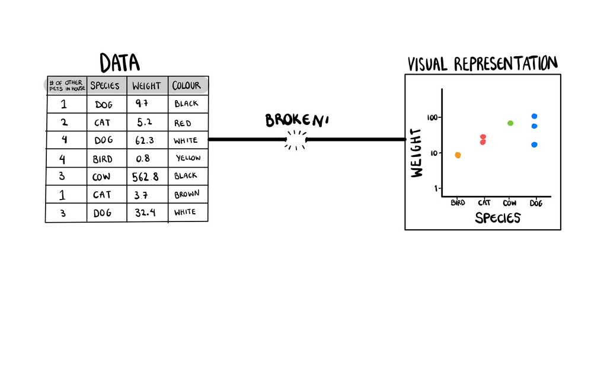

## It happens all the time…

- This is an example from *the grammar of graphics* (Wilkinson 2005)
- What are we uncertain about, exactly?

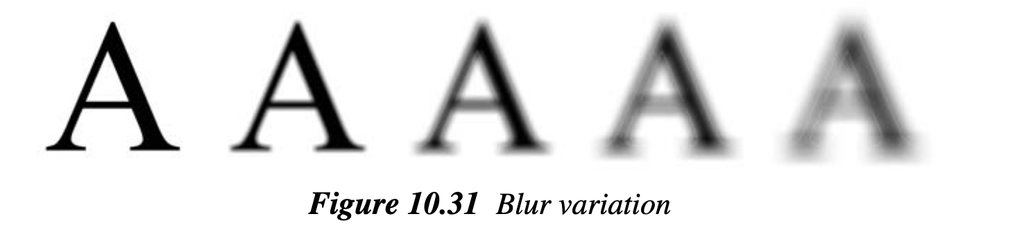

## What an uncertain letter should look like

- If the letter isn’t A it must be *something* else, right? What?
  - Another letter (or a space)
- Uncertainty as a “vibe” might as well be a drawing.

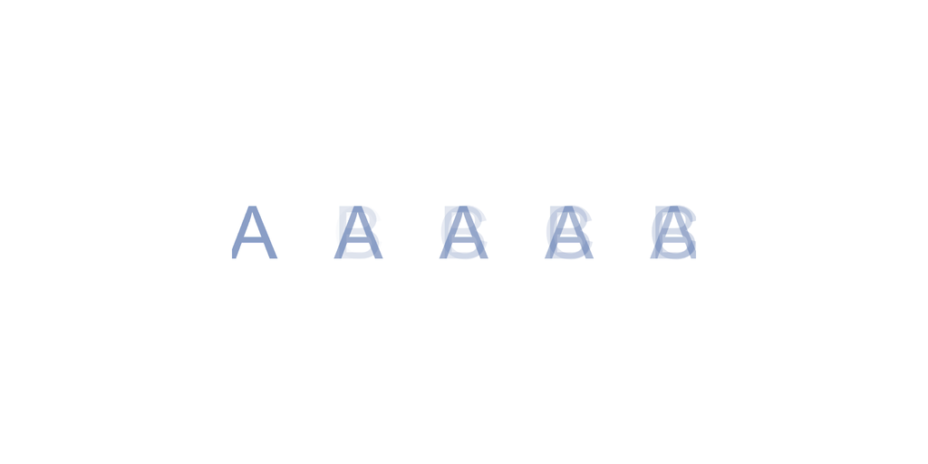

## This mistake is too easy to make

- Good software should help us avoid this pitfall
- Ideally, we have a `ggplot2` extension that does this for every `geom` & `stat`
  - Use `ggplot2` code so people don’t have to learn new syntax
  - If you don’t use `ggplot2`, sorry

## Call this package `ggdibbler`

[figure not shown]

## Main idea of the package

Every `ggdibbler` plot should have a `ggplot2` counterpart, and vice versa

[figure not shown]

## Can’t have any distribution representation

- To get consistent statistical behaviour we cant us:
  - Mean/median brings us back to the original problem
  - PDF changes the visual function (the limit is different)
  - Quantiles need an ordering (problem in figure)
- We can only use samples
  - Need to set the sample size big enough that you get visual convergence

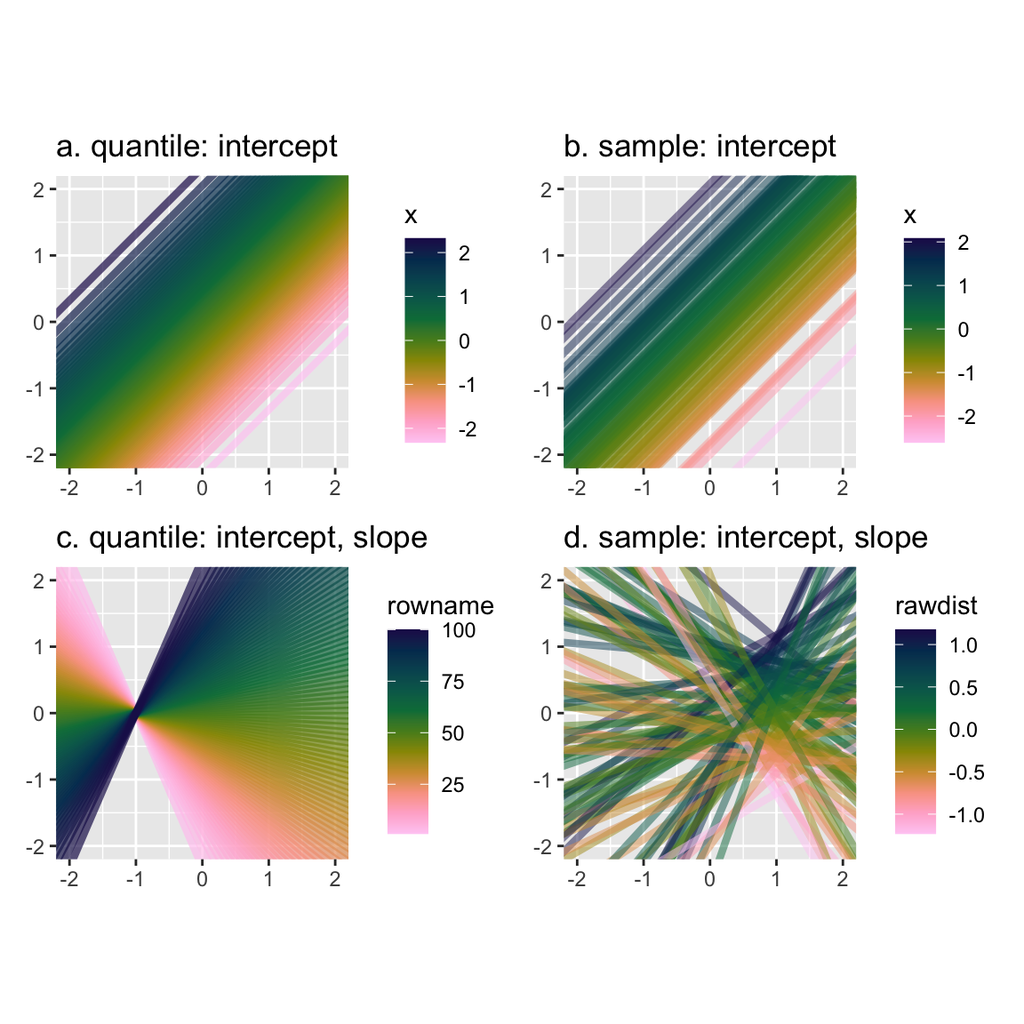

## The visualisation stays the same

We want to communicate that only the input changes

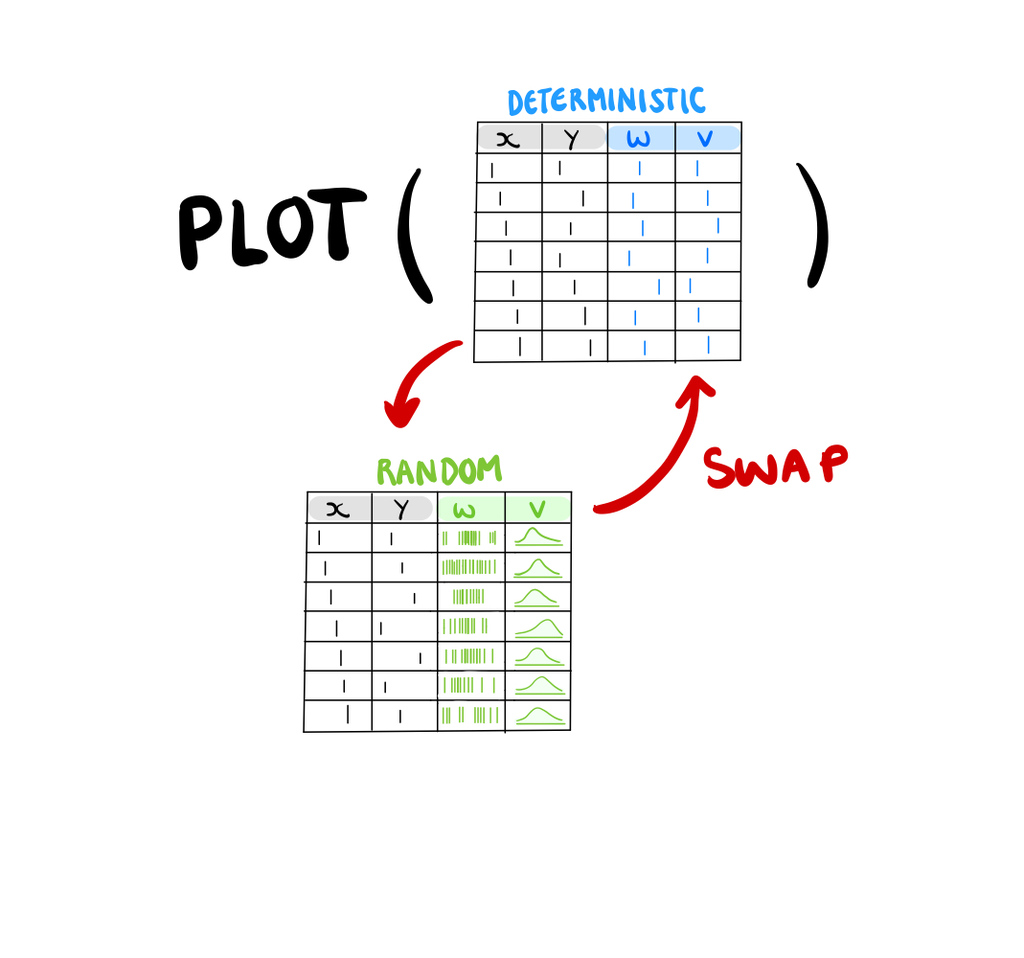

## Minds eye code

The function is the same. The input that different

```r
# determinsitic ggplot
ggplot(deterministic_data) +
  geom_tile(aes(x=x, y=y, fill=z))

# random variable ggplot
ggplot(random_data) +
  geom_tile(aes(x=x, y=y, fill=random_z))
```

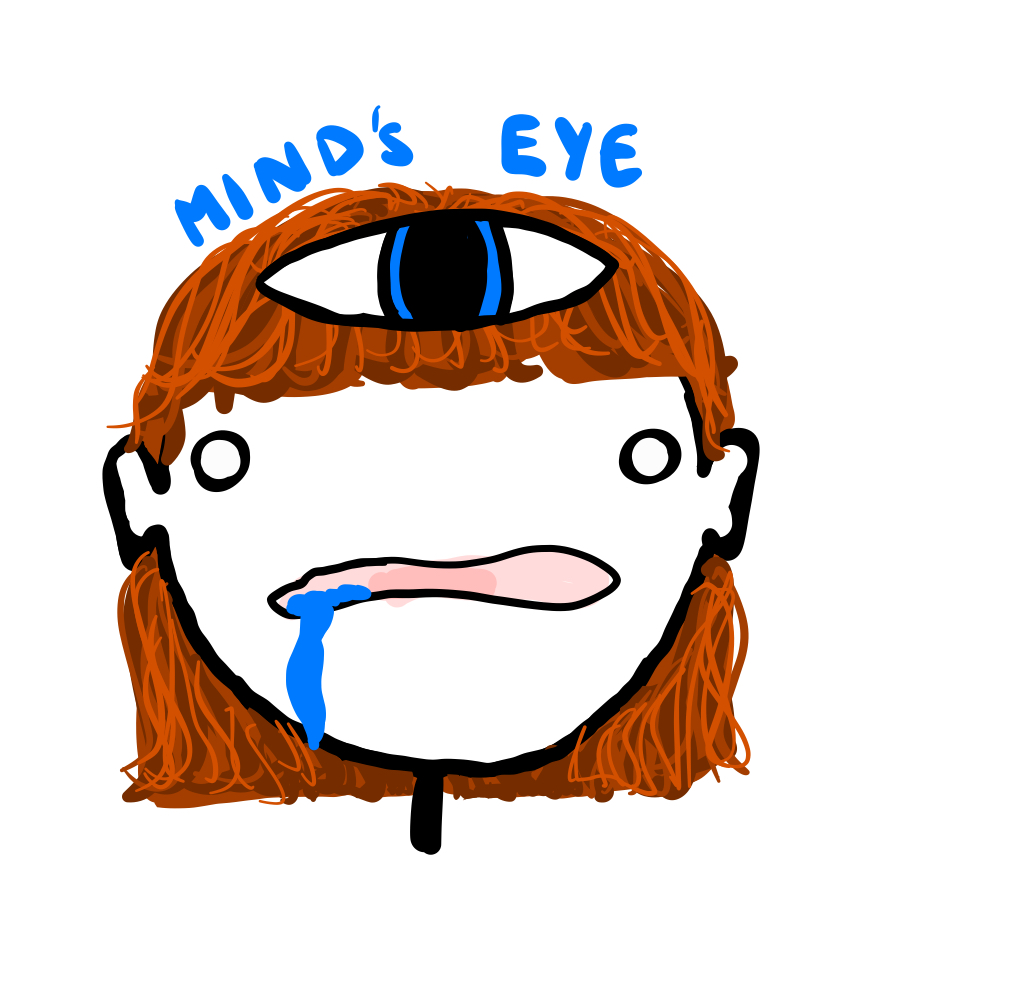

## Hmm

Some `ggplot2` technicalities stop us from being able to do this

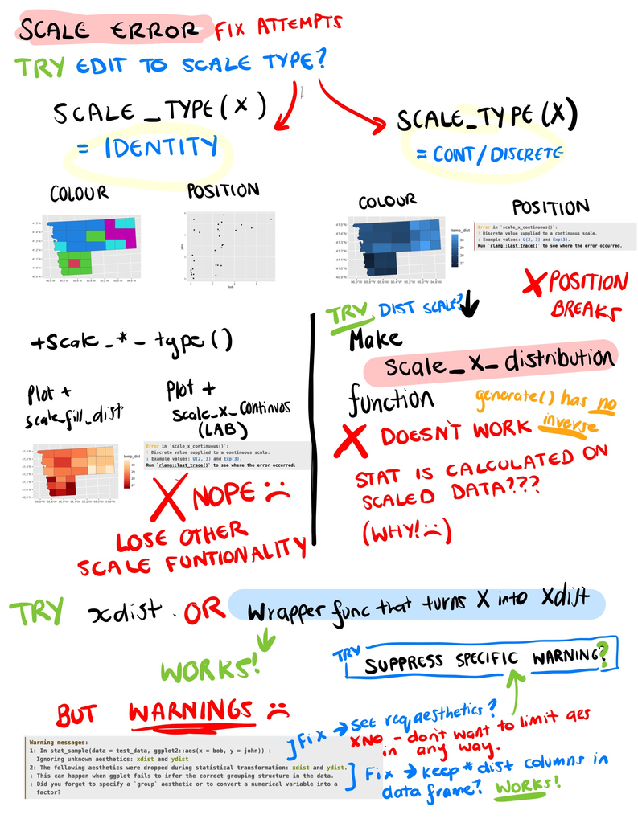

# But we got pretty close!

## Any geom!

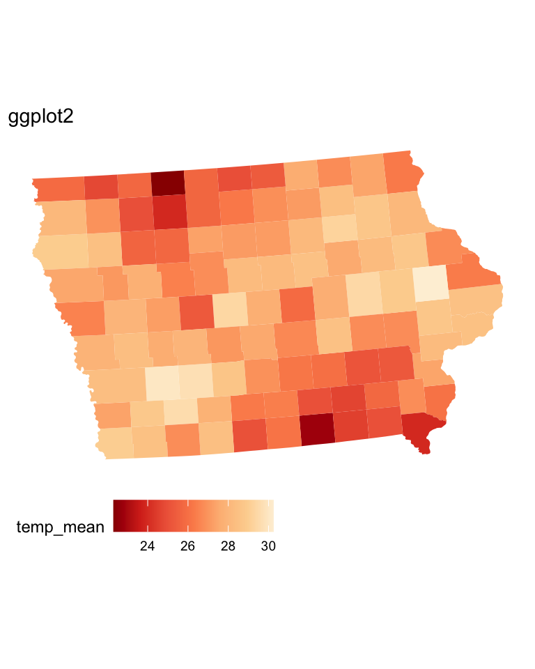

```r
ggplot(toy_temp_mean) +
  geom_sf(aes(geometry=county_geometry, fill=temp_mean), linewidth=0) +
  scale_fill_distiller(palette = "OrRd") +
  theme_map() +
  theme(legend.position = "bottom") +
  ggtitle("ggplot2")
```

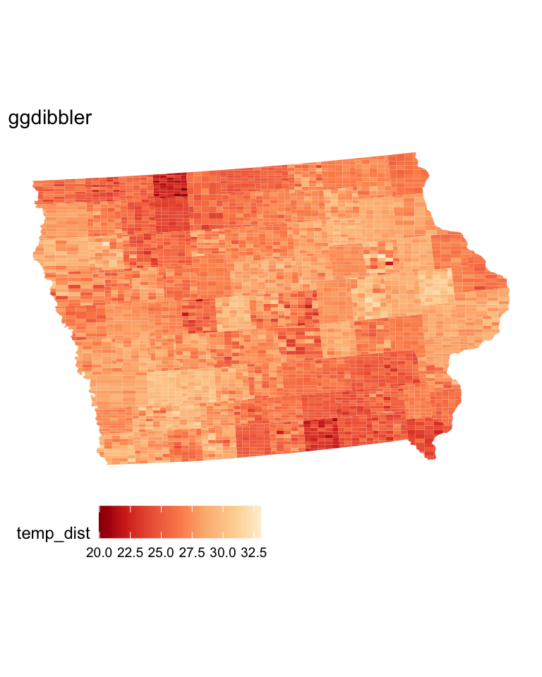

```r
ggplot(toy_temp_dist) +
  geom_sf_sample(aes(geometry = county_geometry, fill=temp_dist), linewidth=0, times=50) +
  scale_fill_distiller(palette = "OrRd") +
  theme_map() +
  theme(legend.position = "bottom") +
  ggtitle("ggdibbler")
```

## Any geom!

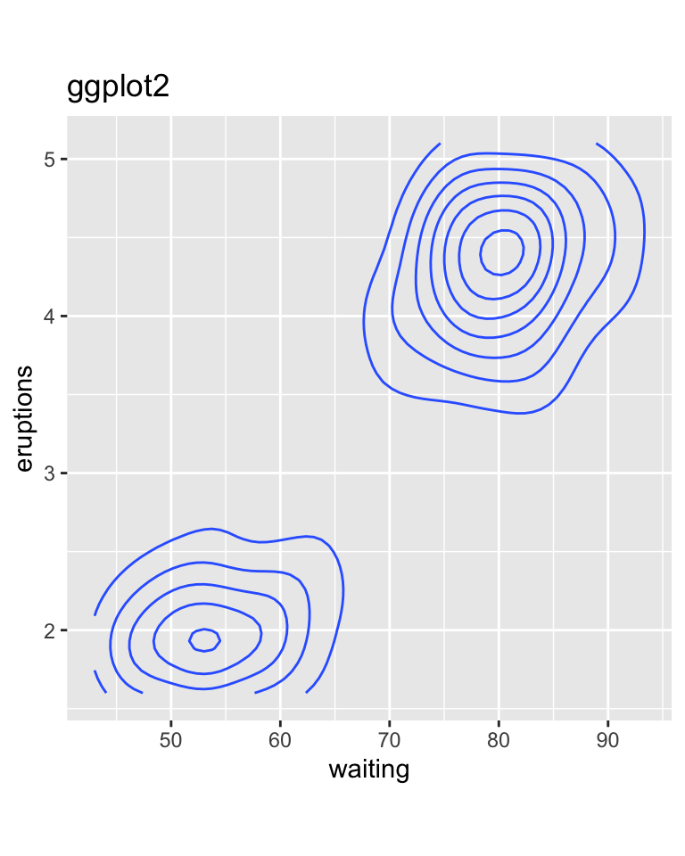

```r
ggplot(faithfuld, aes(waiting, eruptions, z = density)) +
  ggtitle("ggplot2") +
  geom_contour() +
  theme(aspect.ratio = 1)
```

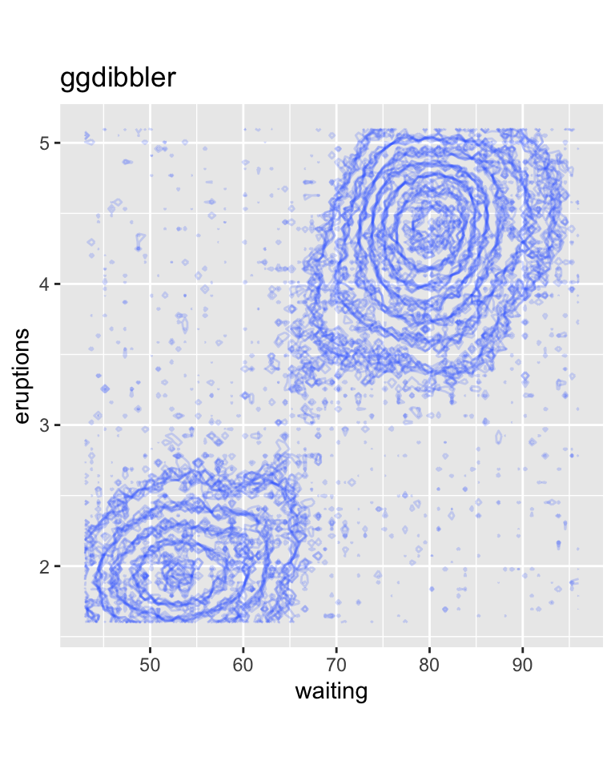

```r
ggplot(uncertain_faithfuld, aes(waiting, eruptions, z = density))+
  ggtitle("ggdibbler") +
  geom_contour_sample(alpha=0.2)+
  theme(aspect.ratio = 1)
```

## Any geom!

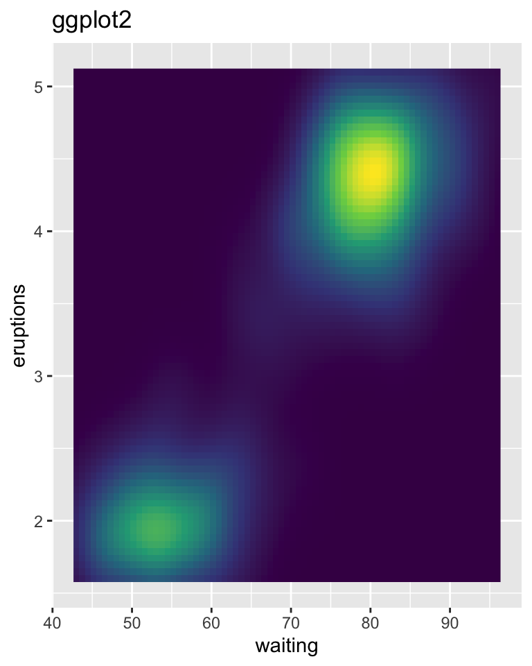

```r
ggplot(faithfuld, aes(waiting, eruptions)) +
  geom_raster(aes(fill = density)) +
  scale_fill_viridis_c() +
  theme(legend.position = "none") +
  ggtitle("ggplot2")
```

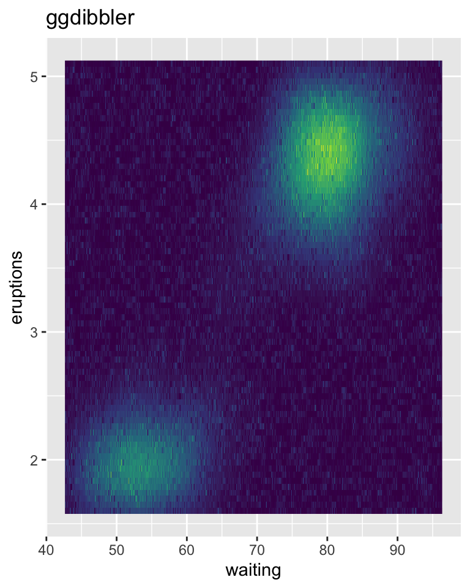

```r
ggplot(uncertain_faithfuld, aes(waiting, eruptions)) +
  geom_raster_sample(aes(fill = density2)) +
  scale_fill_viridis_c() +
  ggtitle("ggdibbler")+
  theme(legend.position = "none")
```

## Any aesthetic!

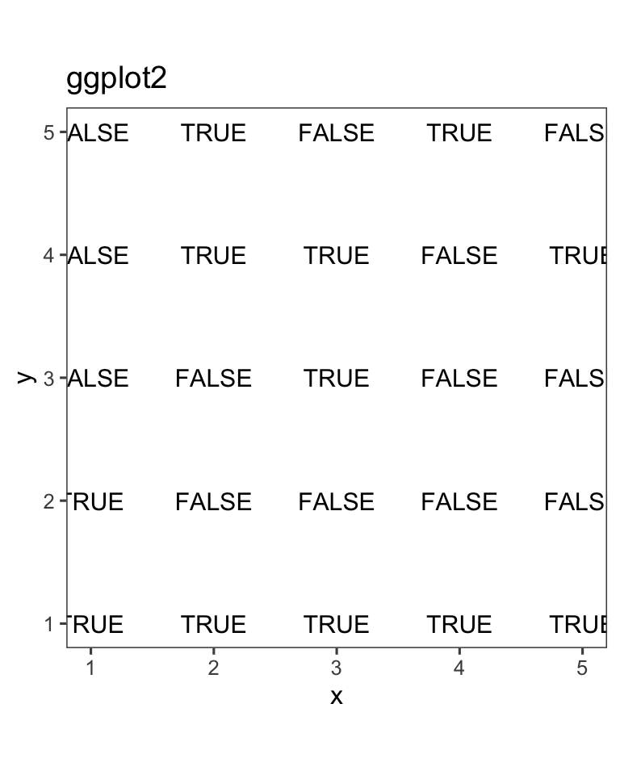

```r
ggplot(textdata, aes(x=x, y=y)) +
  geom_text(aes(label = text_const), size=4) +
  theme_few() +
  ggtitle("ggplot2") +
  theme(aspect.ratio = 1, legend.position = "none")
```

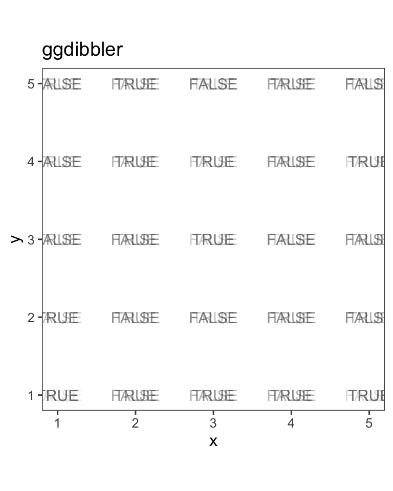

```r
ggplot(textdata, aes(x=x, y=y, lab = text_dist)) +
  geom_text_sample(aes(label = after_stat(lab)), size=4, alpha=1/30, times=30) +
  ggtitle("ggdibbler") +
  theme_few() +
  theme(aspect.ratio = 1, legend.position = "none")
```

## Nested positions let you use…

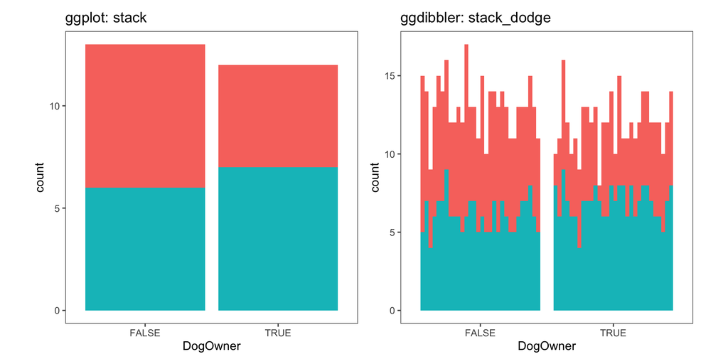

## Any Position!

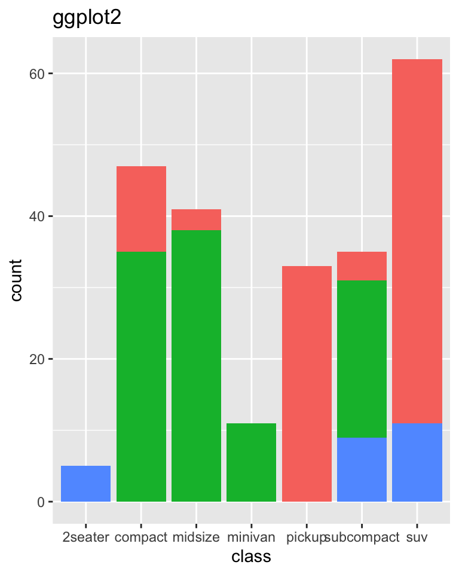

```r
ggplot(mpg, aes(class)) +
  geom_bar_sample(aes(fill = drv),
                  position = "stack")+
  theme(legend.position="none")+
  ggtitle("ggplot2")
```

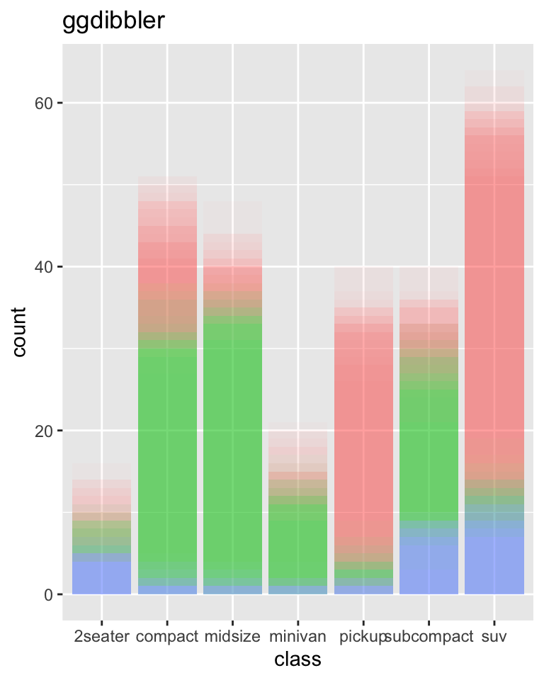

```r
ggplot(uncertain_mpg, aes(class)) +
  geom_bar_sample(aes(fill = drv),times = 30, alpha=1/30,
                  position = "stack_identity")+
  theme(legend.position="none")+
  ggtitle("ggdibbler")
```

## Replicate the `ggplot2` documentation

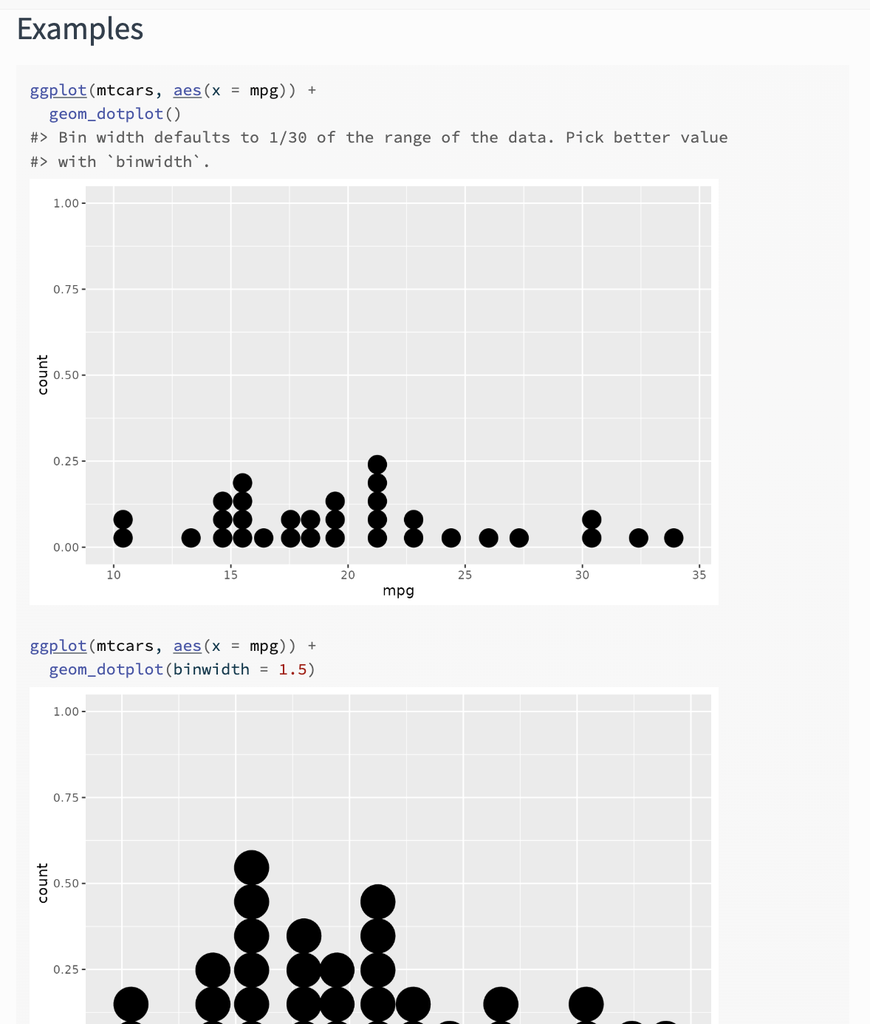

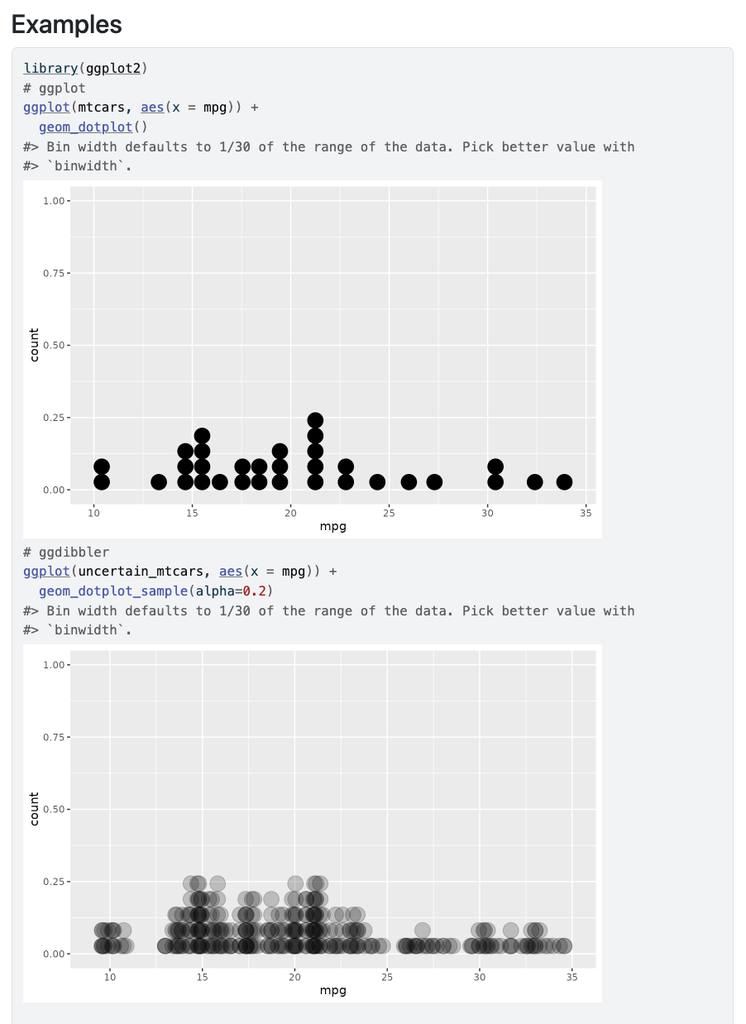

## Uncertainty visualisation neatly bundled up in…

[figure not shown]

## Finally, back to the walktober example

Horray, we can include the measurement uncertainty!

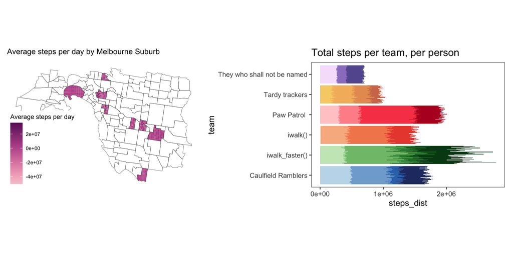

## Acknowledgements

- My supervisors: Di Cook, Susan Vanderplas, and Sarah Goodwin
- Good ideas: Mitch O’Hara-Wild, Cynthia Huang, Emily Robbinson
- AEMO Zema Energy Scholarship
- Australian RTP Stipend
- Numbat Hackathon (for the walktober data)

## References

Bartonicek, Adam, Simon Urbanek, and Paul Murrell. 2025. “No More, No Less Than Sum of Its Parts: Groups, Monoids, and the Algebra of Graphics, Statistics, and Interaction.” *Journal of Computational and Graphical Statistics* 34 (3): 1063–74. https://doi.org/10.1080/10618600.2024.2429708.

Boukhelifa, Nadia, Marc-Emmanuel Perrin, Samuel Huron, and James Eagan. 2017. “How Data Workers Cope with Uncertainty: A Task Characterisation Study.” *Proceedings of the 2017 CHI Conference on Human Factors in Computing Systems* (New York, NY, USA), CHI ’17, 3645–56. https://doi.org/10.1145/3025453.3025738.

Correll, Michael, Dominik Moritz, and Jeffrey Heer. 2018. “Value-Suppressing Uncertainty Palettes.” *Conference on Human Factors in Computing Systems - Proceedings* 2018-April: 1–11. https://doi.org/10.1145/3173574.3174216.

Griethe, Henning, and Heidrun Schumann. 2006. “The Visualization of Uncertain Data: Methods and Problems.” *SimVis* 6: 143–56.

Hullman, Jessica. 2020. “Why Authors Don’t Visualize Uncertainty.” *IEEE Transactions on Visualization and Computer Graphics* 26 (1): 130–39. https://doi.org/10.1109/TVCG.2019.2934287.

Kale, Alex, Francis Nguyen, Matthew Kay, and Jessica Hullman. 2018. “Hypothetical Outcome Plots Help Untrained Observers Judge Trends in Ambiguous Data.” *IEEE Transactions on Visualization and Computer Graphics* 25 (1): 892–902.

Kim, Yea Seul, Logan A. Walls, Peter Krafft, and Jessica Hullman. 2019. “A Bayesian Cognition Approach to Improve Data Visualization.” *Conference on Human Factors in Computing Systems - Proceedings*, 1–14. https://doi.org/10.1145/3290605.3300912.

MacEachren, Alan M. 1992. “Visualizing Uncertain Information.” *Cartographic Perspectives*, no. 13 (June): 10–19. https://doi.org/10.14714/CP13.1000.

Mann, H. B., and A. Wald. 1943. “On Stochastic Limit and Order Relationships.” *The Annals of Mathematical Statistics* 14: 217–26. https://doi.org/10.1214/aoms/1177731415.

Manski, Charles F. 2020. “The Lure of Incredible Certitude.” *Economics and Philosophy* 36 (2): 216–45. https://doi.org/10.1017/S0266267119000105.

Meng, Xiao Li. 2014. “A Trio of Inference Problems That Could Win You a Nobel Prize in Statistics (If You Help Fund It).” *Past, Present, and Future of Statistical Science*, 537–62. https://doi.org/10.1201/b16720-52.

Otsuka, Jun. 2023. *Thinking about Atatistics: The Philosophical Foundations*. 1st ed. Routledge. https://doi.org/10.4324/9781003319061.

Tierney, Nicholas, and Dianne Cook. 2023. “Expanding Tidy Data Principles to Facilitate Missing Data Exploration, Visualization and Assessment of Imputations.” *Journal of Statistical Software* 105 (7): 1–31. https://doi.org/10.18637/jss.v105.i07.

Wilkinson, Leland. 2005. *The Grammar of Graphics*. Springer-Verlag. https://doi.org/10.1007/0-387-28695-0.